# Effect of Text-Based Nudges on Intentions

Preview

vge00

2022-07-01

はじめに、wave 1 target dataを用いて、 我々は意向に対するナッジ・メッセージの効果を推定する。 我々は、クーポン券が自動的に送付されたサブサンプルと送付されなかったサブサンプルの両方で、 個人の観察可能な特徴がトリートメント間でバランスされていることを確認した（補論Bを見よ）。 そこで、本稿にはt検定の結果を掲載して、回帰分析の結果は補論Cに掲載する。 また、検定力80%・有意水準5%を保つために必要な効果の規模を計算したところ、 2019年度にクーポン券が自動で送付される男性のサブサンプルを用いる場合、少なくとも 6.7 %ポイントの差が必要である。 2019年度ではクーポン券を受け取るために手続きが必要な男性のサブサンプルを用いる場合、少なくとも 5 %ポイントの差が必要である。

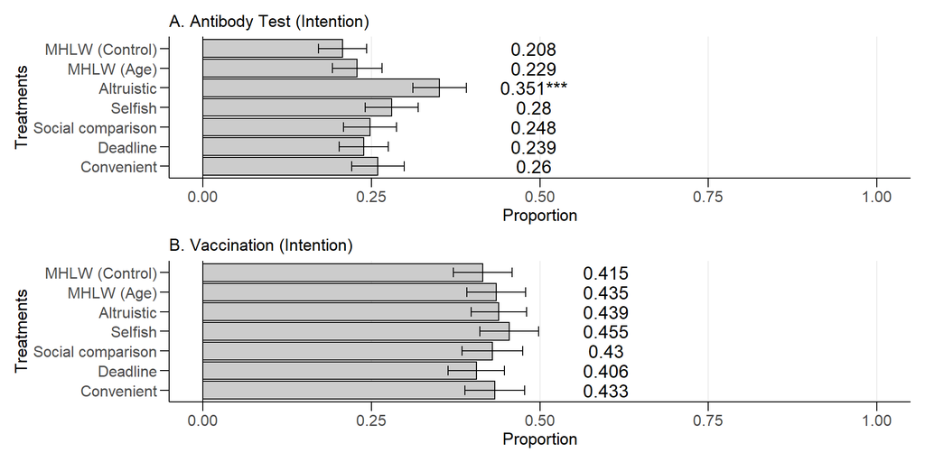

Figure 1: Effect of Text-Based Nudges on Intentions among Men for whom Coupons are Automatically Distributed in FY 2019 (N = 927). Data source: wave 1 selection data. Note: Numbers in the figure indicate the proportion of each group. Error bars indicate standard error of the mean. Asterisks are p-values for t-tests of the difference in means from the MHLW message group: * p < 0.1, ** p < 0.05, *** p < 0.01.

まず、2019年度にクーポン券が自動で送付される男性のサブサンプルを用いて、 我々は各介入群の抗体検査（パネルA）とワクチン接種（パネルB）の意向の比率を 図1に示した。 その結果、利他強調メッセージは厚労省メッセージより抗体検査の意向を高めている。 厚労省メッセージ群の抗体検査の意向の比率は約20.8%であるのに対して、 利他強調メッセージ群の抗体検査の意向の比率は約35.1%である。 したがって、厚労省メッセージと比較して、 利他強調メッセージは抗体検査の意向を約14.3%ポイント高めていて、 これは統計的に1%水準で有意である。 また、この効果サイズは、上述の6.7%ポイントという基準を大きく超えている。

一方で、厚労省メッセージと比較して、 すべてのナッジ・メッセージはワクチン接種の意向を統計的に有意に高めていない。 また、すべての介入群のワクチン接種の意向の比率は抗体検査のそれよりも高いことを注記する。 これはワクチン接種の意向を引き出す質問の刺激によるものだと考えられる。 我々はワクチン接種の意向を回答者に尋ねるとき、抗体を保有していないことを条件にしている。 この条件がワクチン接種の必要性を強く刺激している可能性がある。 したがって、ナッジ・メッセージのワクチン接種の意向に対する効果はなかったとしても、 実際のワクチン接種の行動に対する効果はあるかもしれない。

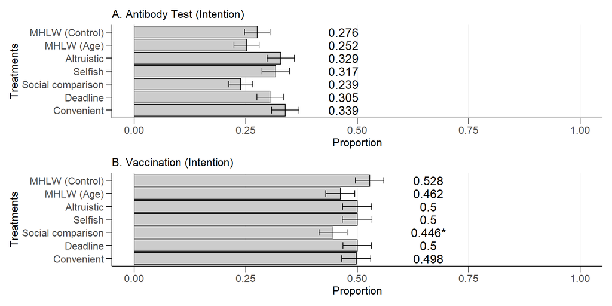

Figure 2: Effect of Text-Based Nudges on Intentions among Men Who Needed Costly Procedures to Receive Coupons in FY 2019 (N = 1,688). Data source: wave 1 selection data. Note: Numbers in the figure indicate the proportion of each group. Error bars indicate standard error of the mean. Asterisks are p-values for t-tests of the difference in means from the MHLW message group: * p < 0.1, ** p < 0.05, *** p < 0.01.

次に、2019年度にクーポン券を得るためにコストのかかる手続きが必要な男性のサブサンプルを用いて、 我々は各介入群の抗体検査（パネルA）とワクチン接種（パネルB）の意向の比率を 図2に示した。 その結果、厚労省メッセージと比較して、 利他強調メッセージを含めて、 すべてのナッジ・メッセージは抗体検査の意向を統計的に有意に高めていない。

対照的に、 社会比較メッセージは厚労省メッセージよりもワクチン接種の意向を低めている可能性が示唆された。 厚労省メッセージのワクチン接種の意向比率は約52.8%であるのに対し、 社会比較メッセージのワクチン接種の意向比率は約44.6%である[^1]。 したがって、厚労省メッセージと比較して、 社会比較メッセージはワクチン接種の意向を約8.2%ポイント低めており、 これは統計的に10%水準で有意である。 この効果の原因の一つとして、ワクチン接種のただのりが挙げられる。 社会比較メッセージは「5人に1人が抗体を持っていない」ことを強調している。 裏返せば、5人に4人が抗体を持っているということである。 このメッセージを読んだ人は、 仮に風しんの抗体を保有していないとしても、全体の80% が抗体を持っているので、 自身が感染する機会は少ないと考えたのかもしれない。 クーポン券を受け取るために手続きが必要なとき、 この信念がワクチンを接種することの価値を低め、 ワクチン接種の意向の比率を厚労省メッセージよりも下げた可能性がある。

Table 1: Linear Probability Model of Intentions

Antibody Test

Vaccination

MHLW (Age)

－0.033

－0.075*

(0.038)

(0.043)

Altruistic

0.044

－0.040

(0.041)

(0.044)

Selfish

0.014

－0.058

(0.040)

(0.044)

Social comparison

－0.050

－0.095**

(0.038)

(0.043)

Deadline

0.024

－0.033

(0.039)

(0.043)

Convenient

0.056

－0.035

(0.041)

(0.044)

Coupon

－0.080

－0.075

(0.051)

(0.062)

Coupon×Age expression

0.057

0.102

(0.063)

(0.075)

Coupon×Altruistic

0.105

0.066

(0.065)

(0.073)

Coupon×Selfish

0.093

0.135*

(0.065)

(0.075)

Coupon×Social comparison

0.120*

0.138*

(0.063)

(0.075)

Coupon×Valid date

0.005

0.023

(0.062)

(0.073)

Coupon×Low-cost

－0.002

0.059

(0.064)

(0.075)

Num.Obs.

2615

2615

R2

0.337

0.502

R2 Adj.

0.331

0.497

Covariates

X

X

* p < 0.1, ** p < 0.05, *** p < 0.01

Table 2: Effects of Text-Based Nudges on Intentions Using Linear Probability Model Estimates

| How to get coupons | Text-based nudges | Antibody Test estimate | Antibody Test std.error | Antibody Test p.value | Vaccination estimate | Vaccination std.error | Vaccination p.value |
| --- | --- | --- | --- | --- | --- | --- | --- |
| Costly procedure | MHLW (Age) | －0.033 | 0.038 | 0.380 | －0.075 | 0.043 | 0.084 |
|  | Altruistic | 0.044 | 0.041 | 0.292 | －0.040 | 0.044 | 0.360 |
|  | Selfish | 0.014 | 0.040 | 0.727 | －0.058 | 0.044 | 0.189 |
|  | Social comparison | －0.050 | 0.038 | 0.186 | －0.095 | 0.043 | 0.026 |
|  | Deadline | 0.024 | 0.039 | 0.536 | －0.033 | 0.043 | 0.440 |
|  | Convenient | 0.056 | 0.041 | 0.165 | －0.035 | 0.044 | 0.421 |
| Automatic receiving | MHLW (Age) | 0.024 | 0.050 | 0.630 | 0.027 | 0.061 | 0.660 |
|  | Altruistic | 0.149 | 0.050 | 0.003 | 0.026 | 0.058 | 0.662 |
|  | Selfish | 0.107 | 0.051 | 0.034 | 0.077 | 0.061 | 0.209 |
|  | Social comparison | 0.070 | 0.051 | 0.172 | 0.043 | 0.062 | 0.483 |
|  | Deadline | 0.030 | 0.048 | 0.541 | －0.011 | 0.059 | 0.855 |
|  | Convenient | 0.055 | 0.050 | 0.272 | 0.024 | 0.060 | 0.688 |

Table 3: Effects of Text-Based Nudges on Intentions Using Linear Probability Model Estimates (Baseline: Altruistic Message)

| How to get coupons | Text-based nudges | Antibody Test estimate | Antibody Test std.error | Antibody Test p.value | Vaccination estimate | Vaccination std.error | Vaccination p.value |
| --- | --- | --- | --- | --- | --- | --- | --- |
| Costly procedure | MHLW (Age) | －0.077 | 0.041 | 0.059 | －0.035 | 0.045 | 0.440 |
|  | Selfish | －0.030 | 0.043 | 0.490 | －0.018 | 0.046 | 0.697 |
|  | Social comparison | －0.093 | 0.040 | 0.021 | －0.055 | 0.044 | 0.216 |
|  | Deadline | －0.019 | 0.042 | 0.648 | 0.007 | 0.045 | 0.875 |
|  | Convenient | 0.013 | 0.043 | 0.766 | 0.005 | 0.045 | 0.907 |
| Automatic receiving | MHLW (Age) | －0.125 | 0.052 | 0.017 | 0.001 | 0.058 | 0.982 |
|  | Selfish | －0.042 | 0.053 | 0.435 | 0.051 | 0.058 | 0.377 |
|  | Social comparison | －0.079 | 0.054 | 0.142 | 0.018 | 0.059 | 0.762 |
|  | Deadline | －0.119 | 0.051 | 0.020 | －0.036 | 0.056 | 0.518 |
|  | Convenient | －0.094 | 0.052 | 0.072 | －0.001 | 0.057 | 0.983 |

クーポン券が自動的に送付されるかどうかは年齢で決まるので、 サブサンプルを用いたナッジ・メッセージの効果は クーポン券が自動的に送付されるかどうかだけでなく、 二つのサブサンプルの年齢の違いの影響を受けている。 この問題を排除するために、我々は以下のような意向の線形確率モデルを推定した。
$$\begin{align}
Y_{ij} = \alpha + \sum_j \beta_j \text{Message}_j
+ \sum_j \gamma_j (\text{Message}_j \times \text{Coupon}_i)
+ \delta \text{Coupon}_i + \lambda X'_{ij} + \epsilon_{ij},
\end{align}$$
ここで、$\text{Message}_j$は厚労省メッセージ群をコントロールとした介入群ダミーであり、 $\text{Coupon}_i$はクーポン券の自動送付を受け取ったことを示すダミー変数である。 $X$は個人の共変量ベクトルであり、年齢を含む。

表1は線形確率モデルの結果である。また、 表2は 線形確率モデルの推定値を用いたナッジ・メッセージの効果である。 本論で示したt検定の結果と同様に、 2019年度にクーポン券が自動的に送付される男性における 利他強調メッセージの抗体検査の意向に対する効果は統計的に有意であるが、 2019年度にクーポン券を取得するために手続きが必要な男性における 利他強調メッセージの抗体検査の意向に対する効果は統計的に非有意である。 さらに、表1より、この二つの効果の差は統計的に非有意である。

表3は利他強調メッセージをコントロールとした 他のナッジ・メッセージの効果の推定結果である。 2019年度にクーポン券を受け取るためにはコストのかかる手続きが必要な男性における ナッジ・メッセージの効果の差は$\beta_j - \beta_{\text{Altruistic}}$ で得られる。 2019年度にクーポン券を自動的に受け取った男性における ナッジ・メッセージの効果の差は$(\beta_j + \gamma_j) - (\beta_{\text{Altruistic}} + \gamma_{\text{Altruistic}})$ で得られる。 2019年度にクーポン券が自動的に送付される男性に限定したとき、 利己強調メッセージ・社会比較メッセージの抗体検査の意向は 利他強調メッセージのそれと統計的に有意に異ならない。 この意味で、利己強調メッセージや社会比較メッセージは 抗体検査の意向を促進している可能性がある。 しかしながら、検出力を十分に保てるほどの差ではないので、 サンプルサイズを大きくして再度検証すべきである。

[^1]: 2019年度にクーポン券が自動で送付される男性のサブサンプルを用いた結果と同様に、 すべての介入群のワクチン接種の意向比率は抗体検査のそれよりも高い。 これはワクチン接種の意向を引き出す質問の刺激によるものだと考えられる。